# Guía Supuestos de la Regresión lineal

OCE 386 - Introducción al análisis de datos con R.

Dr. José A. Gallardo.

Pontificia Universidad Católica de Valparaíso  
jose.gallardo@pucv.cl

09 November 2021

### MODELOS LINEALES

Los modelos lineales son ampliamente utilizados en oceanigrafía para explicar, modelar o predecir la relación lineal de una variable respuesta $Y$ con una o más variables predictoras $X_1,…,X_p$.

$$Y_{i} = \beta_{0} + \beta_{1} X_{i1} + \beta_{2} \beta_{i2} + ... + \beta_{p} X_{ip} + \epsilon_{i}$$

Supuestos: $Y_i$ se distribuye **normalmente**

- Si **p = 1**, el modelo es una regresión *lineal simple*.
- Si **p > 1**, el modelo es una regresión *lineal múltiple*.
- Si **p > 1** y alguna variable predictora es **categórica**, el modelo se denomina *ANCOVA*.

### PRUEBA DE HIPÓTESIS: COEFICIENTE DE REGRESIÓN E INTERCEPTO

*Prueba de hipótesis del coeficiente de regresión y el intercepto*

La hipótesis nula en ambos casos es que el coeficiente del intercepto ($β_0$) y de la pendiente ($β_1$) son iguales a 0.

$H_0:β_0 = 0$ y $H_0:β_1 = 0$

### PREDICCIÓN A PARTIR DEL MODELO DE REGRESIÓN LINEAL SIMPLE

El Coeficiente de determinación (*R²*) se calcula como el **cuadrado del coeficiente de correlación de pearson**. Este nos indica que tan buena es la predicción que el modelo hace de los datos.

El R cuadrado ajustado (*R² ajustado*) nos dice qué porcentaje de la variación de la variable dependiente es explicado por la o las variables independientes de manera conjunta. En un modelo de regresión lineal, el **R² ajustado** es una medida de bondad que considera el número de variables existentes en el modelo.

$$R^2_{ajust} =1-(1-R^2)\frac{n-1}{n-p-1}$$

donde:

$n$ = tamaño de la muestra

$p$ = cantidad de variables predictoras en el modelo

*Prueba de hipótesis del modelo completo*

La hipótesis nula es si los coeficientes son iguales a 0.

$H_0:β_j = 0$ ; $j = 1, 2,...,k$

#### **Objetivos de aprendizaje**

Los objetivos de aprendizaje de esta guía son:

**1**. - Realizar evaluación de supuestos de una regresión lineal.

**2**. - Realizar gráficas avanzadas con ggplot2.

**3**. - Elaborar un reporte dinámico en formato pdf con **[Rmarkdown](https://rmarkdown.rstudio.com/)**.

## ESTUDIO DE CASO: PREDICCIÓN DE TEMPERATURA AEREA EN RIOS.

En este estudio de caso trabajaremos con un set de datos real obtenido de una investigación científica.

La variable respuesta se denomina **AirTemp_observed** y se expresa en grados celcius. Para este set de datos existen dos variables predictoras denominadas **WaterTemp** y **Site** que corresponde a la temperatura superficial de diferentes ríos.

El objetivo es realizar una regresión lineal entre **AirTemp_observed** y **WaterTemp** evaluando los supuestos del modelo de regresión lineal.

### **Ejercicio 1.** Elaborar y configurar Reporte en formato .Rmd

Elabore un documento .Rmd y configure su reporte para exportar en .pdf. Instale solo las liberías que utilice para el análisis de los datos.

```r
knitr::opts_chunk$set(echo = TRUE)
library(readxl)
library(dplyr)
library(ggplot2)
library(UsingR)
library(ggpmisc)
library(knitr)
library(car)
library(lmtest)
```

Ejecute cada uno de los siguientes ejercicios en uno o más bloques de códigos diferentes. Sea ordenado y documente su reporte adecuadamente.

Importe el set de datos **Temperature_dat.xlsx** y transforme solo la variable **Site** a factor, luego realice un análisis exploratorio de datos.

Incluya:

**a).** Resumen estadístico de todas las variables.

```r
Tem_rivers <- read_excel("Temperature_dat.xlsx")

Tem_rivers$Site <- as.factor(Tem_rivers$Site)
summary(Tem_rivers)
```

```
##       Site          Date                       WaterTemp     AirTemp_observed
##  BR11LCP: 48   Min.   :2012-06-23 00:00:00   Min.   :11.96   Min.   :12.97
##  BR1MP  : 48   1st Qu.:2012-07-04 18:00:00   1st Qu.:17.61   1st Qu.:20.64
##  BR5LCP : 48   Median :2012-07-16 12:00:00   Median :18.90   Median :21.96
##  HUR1MP : 48   Mean   :2012-07-16 12:00:00   Mean   :18.70   Mean   :21.99
##  HUR5LCP: 48   3rd Qu.:2012-07-28 06:00:00   3rd Qu.:20.04   3rd Qu.:23.49
##  HUR9LCP: 48   Max.   :2012-08-09 00:00:00   Max.   :24.64   Max.   :28.87
##  (Other):960
```

**c).** realice un histograma de la variable respuesta **AirTemp_observed** y de la variable predictora **WaterTemp**.

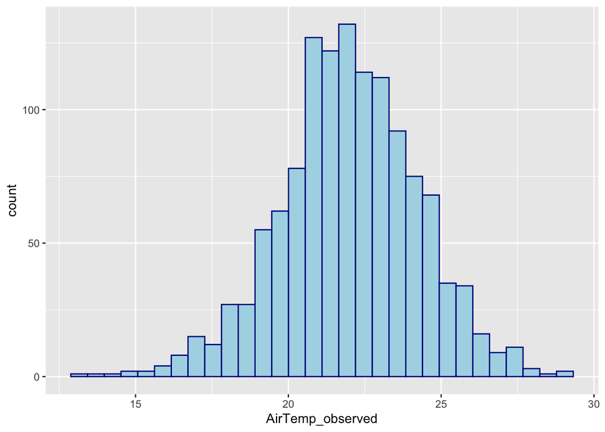

```r
ggplot(Tem_rivers, aes(x=AirTemp_observed))+
  geom_histogram(color="darkblue", fill="lightblue")
```

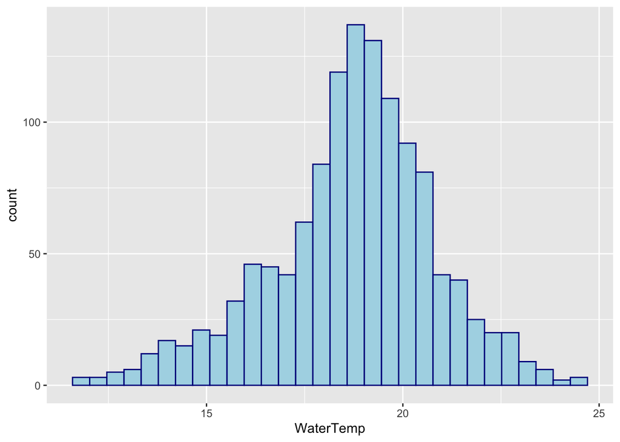

```r
ggplot(Tem_rivers, aes(x=WaterTemp))+
  geom_histogram(color="darkblue", fill="lightblue")
```

### **Ejercicio 3.** Regresión lineal simple.

**a).** Realice una gráfica de dispersión (geom_point) de **AirTemp_observed** en función de **WaterTemp**, incluya el comando **geom_smooth(method=lm)** para agregar la línea de regresión a la gráfica.

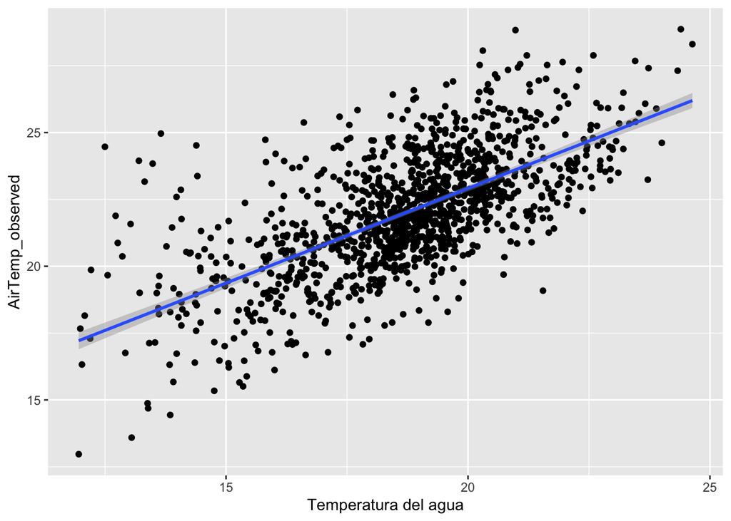

```r
p <- ggplot(Tem_rivers, aes(x = WaterTemp, y = AirTemp_observed))
p + geom_point() + xlab("Temperatura del agua") + geom_smooth(method=lm)
```

**b).** Realice un análisis de regresión lineal para investigar la asociación entre **AirTemp_observed** y **WaterTemp** usando las funciones **lm()**, **summary()**. Interprete los resultados del modelo lineal y responda las siguientes preguntas. ¿Qué representa el estimador de WaterTemp y del intercepto?. ¿La pendiente es significativamente distinta de cero?. ¿Y el intercepto?

```r
lm.tem <- lm(AirTemp_observed ~ WaterTemp, data = Tem_rivers)
summary(lm.tem)
```

```
##
## Call:
## lm(formula = AirTemp_observed ~ WaterTemp, data = Tem_rivers)
##
## Residuals:
##     Min      1Q  Median      3Q     Max
## -4.9237 -1.1218 -0.1740  0.9731  6.8693
##
## Coefficients:
##             Estimate Std. Error t value Pr(>|t|)
## (Intercept)  8.74581    0.43158   20.27   <2e-16 ***
## WaterTemp    0.70831    0.02293   30.88   <2e-16 ***
## ---
## Signif. codes:  0 '***' 0.001 '**' 0.01 '*' 0.05 '.' 0.1 ' ' 1
##
## Residual standard error: 1.71 on 1246 degrees of freedom
## Multiple R-squared:  0.4336, Adjusted R-squared:  0.4331
## F-statistic: 953.8 on 1 and 1246 DF,  p-value: < 2.2e-16
```

### **Ejercicio 4.** Evalue supuestos del modelo

**a).** Evalue normalidad del modelo usando métodos gráficos y prueba de shapiro.

```r
shapiro.test (residuals (lm.tem ))
```

```
##
##  Shapiro-Wilk normality test
##
## data:  residuals(lm.tem)
## W = 0.98703, p-value = 4.335e-09
```

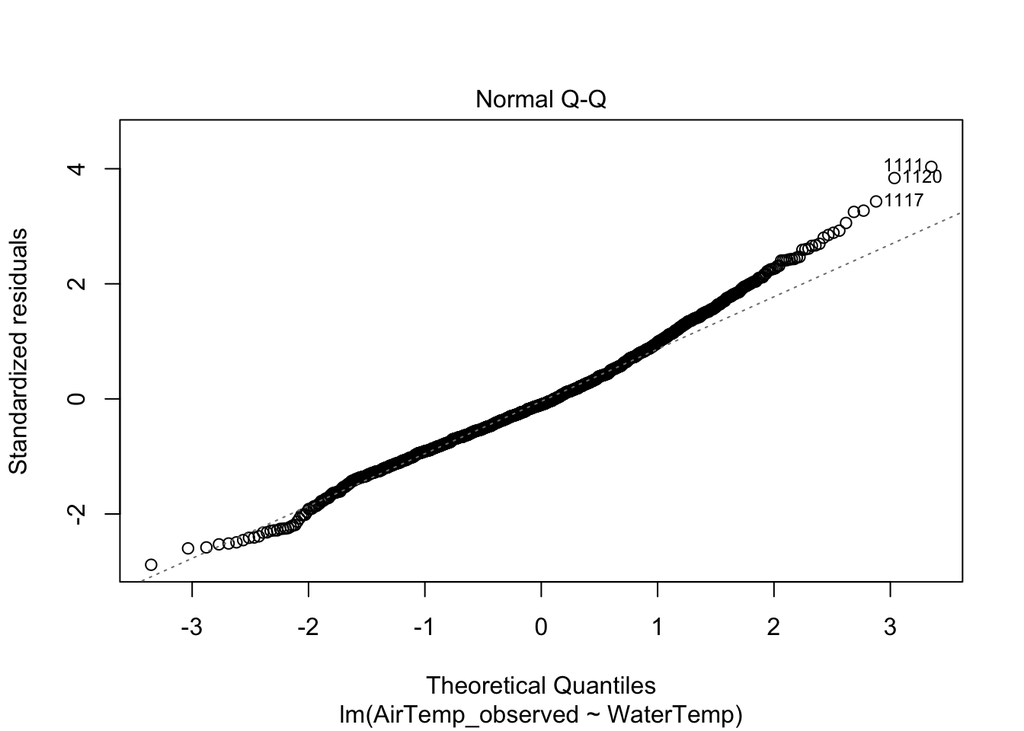

```r
plot(lm.tem , which = 2)
```

**b).** Evalue homogeneidad de varianzas usando el comando plot.

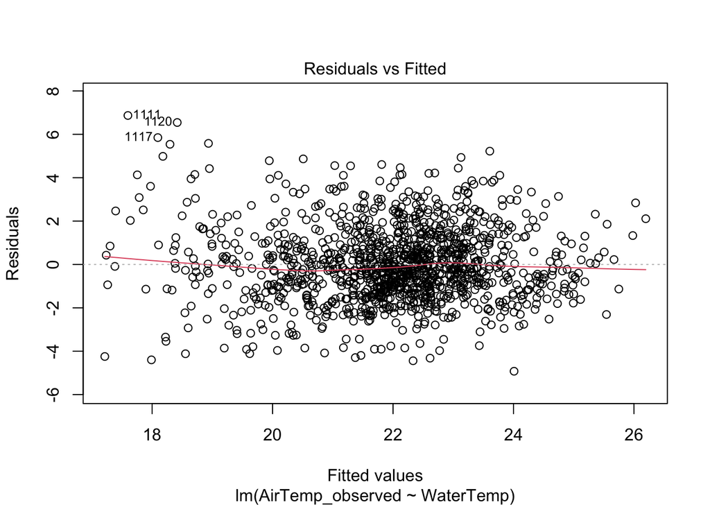

```r
plot(lm.tem , which = 1)
```